# PhD Chapter 3 - RelativeSize

##### Untransformed data

Following this initial inspection, we proceed to analyse differences among ecosystems. Our first step involves filtering the data to isolate the relevant data for analysis. Specifically, we exclude data points where the response variable couldn’t be computed, as well as time points preceding the initial disturbance and resource flow. Then we plot the data to make sure that what filtered the data in the right way.

```r
filtered_data = ds_ecosystems %>%
  filter(trophic_type == trophy_selected,
         time_point >= first_time_point_model,
         time_point <= last_time_point_model,!is.na(!!sym(response_variable))) %>%
  mutate(ecosystem_ID = as.character(ecosystem_ID))
```

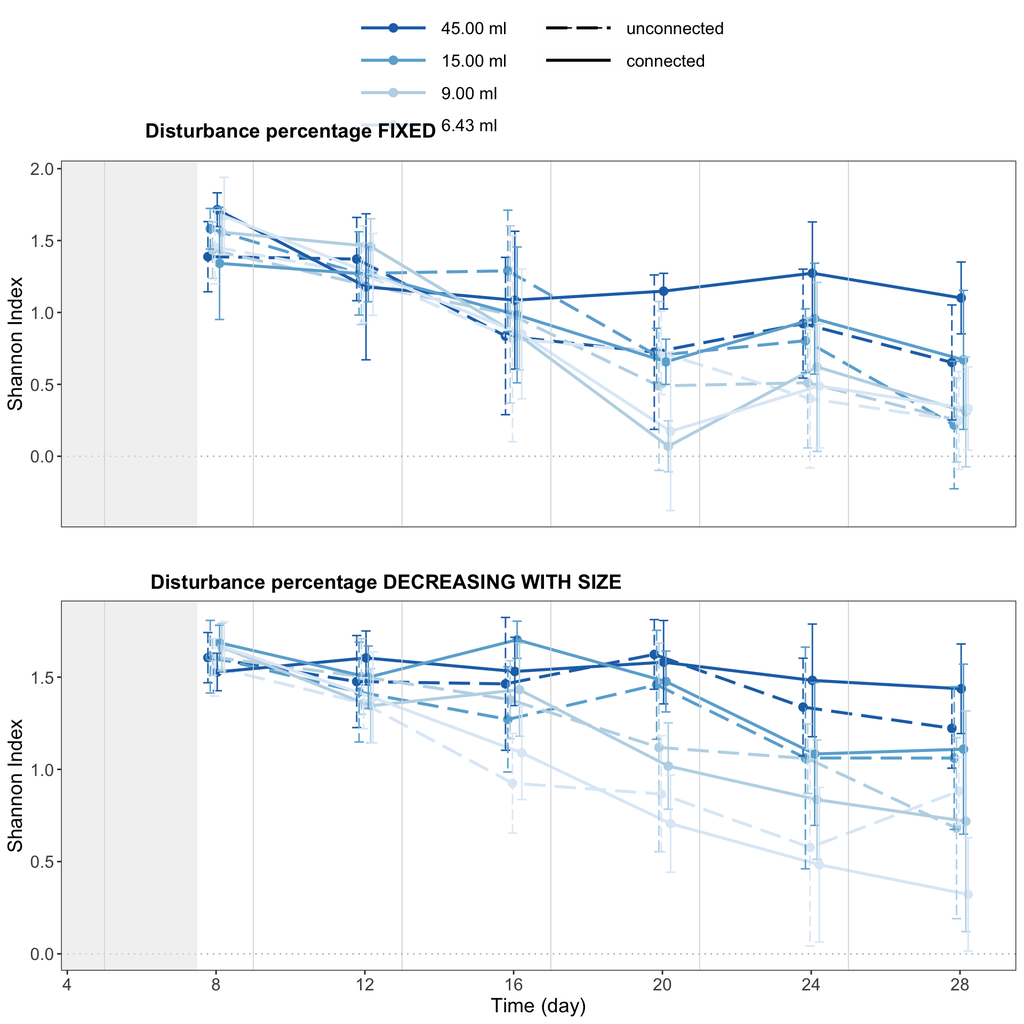

```r
ggarrange(plot.ecosystems.points(filtered_data %>% filter(disturbance_percentage == "fixed"),
                                 trophy_selected,
                                 response_variable,
                                 legend_row_n_input = 4) +
            rremove("xlab") +
            theme(axis.text.x = element_blank(),
                  axis.ticks.x = element_blank()) +
            font("legend.text", size = size_legend) +
            font("ylab", size = size_y_axis),
          NULL,
          plot.ecosystems.points(filtered_data %>% filter(disturbance_percentage == "decreasing_with_size"),
                                 trophy_selected,
                                 response_variable,
                                 legend_row_n_input = 4) +
            font("legend.text", size = size_legend) +
            font("xlab", size = size_y_axis) +
            font("ylab", size = size_y_axis) +
            scale_x_continuous(breaks = unique(ds_metaecosystems$day)) +
            theme(legend.position = "none"),
          heights = c(1, 0.1, 0.8),
          nrow = 3,
          align = "v",
          labels = c(fixed_label, "", relative_label),
          label.x = c(0, 0, -0.083),
          label.y = c(0.785, 0, 1.06))
```

**View single treatments: for each size connected vs unconnected**

```r
fixed_label
```

```
## [1] "Disturbance percentage FIXED"
```

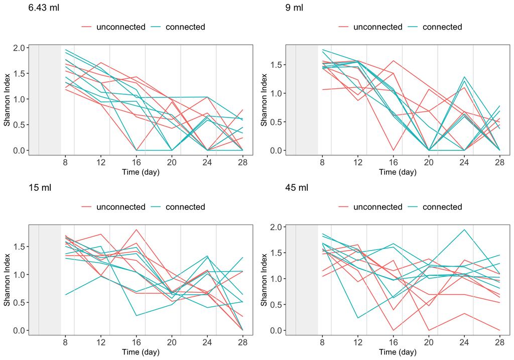

```r
plot.ecosystems.sizes.one.by.one(filtered_data,
                                      trophy_selected,
                                      disturbance_percentage_selected = "fixed",
                                      response_variable)
```

```r
relative_label
```

```
## [1] "Disturbance percentage DECREASING WITH SIZE"
```